# Project 2

*Kenneth Luna*

```r
library("forecast")
library("tseries")
```

```r
data <- read.csv("tsla.csv")
data$Date <- as.Date(data$Date, "%d-%b-%y")
data <- data[order(data$Date),]

date <- as.Date(data$Date, "%d-%b-%y")
time <- 1:length(date)
tsla <- data$Close
```

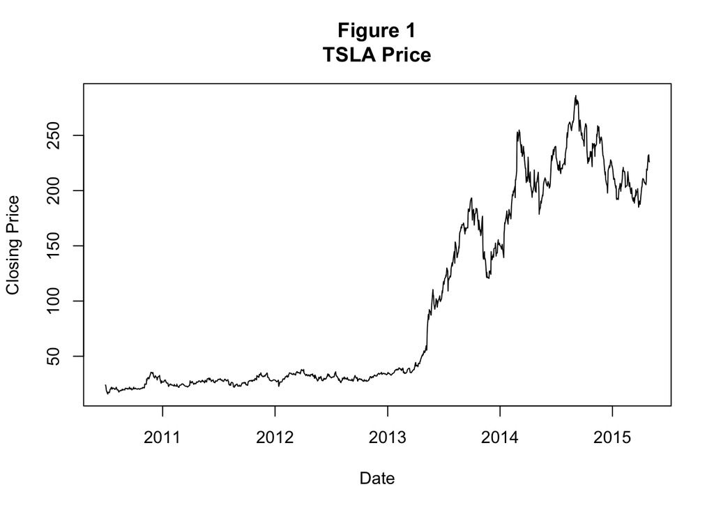

```r
par(mfrow=c(1,1))
plot(date, tsla, type="l",
     xlab="Date", ylab="Closing Price", main = "Figure 1\nTSLA Price")
```

Convert closing stock price to log.tsla.

```r
log.tsla <- log(tsla)
```

## Problem 1

Here is a time series plot of log.tsla, along with the ACF and PACF:

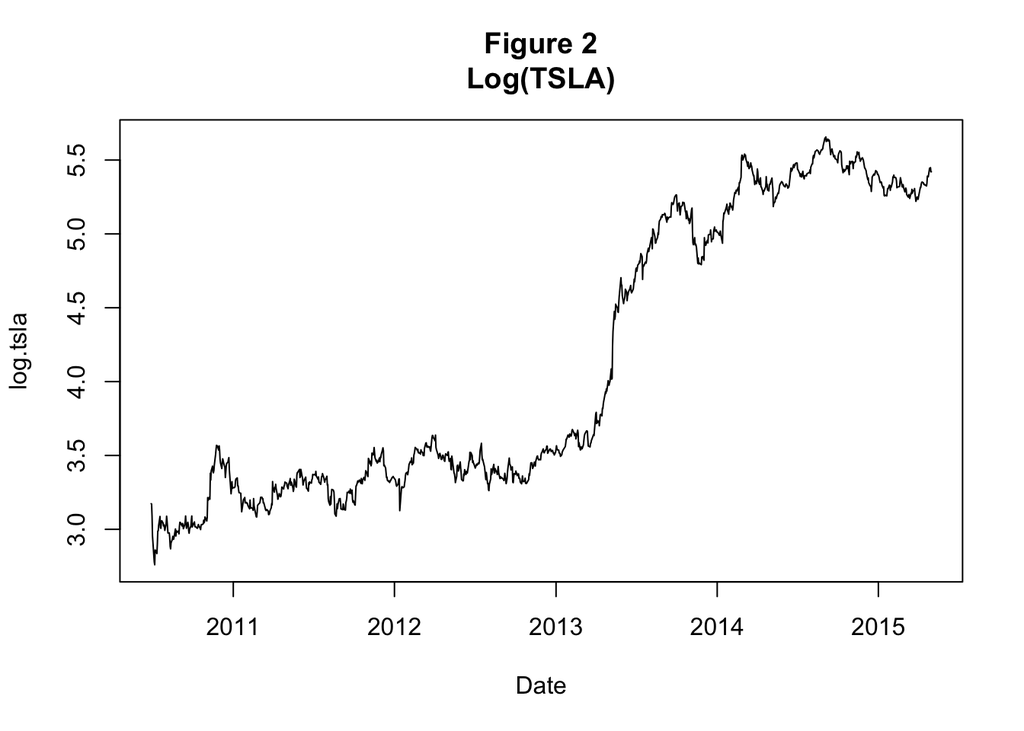

```r
par(mfrow=c(1,1))
plot(date, log.tsla, type="l",
     xlab="Date", ylab="log.tsla", main = "Figure 2\nLog(TSLA)")
```

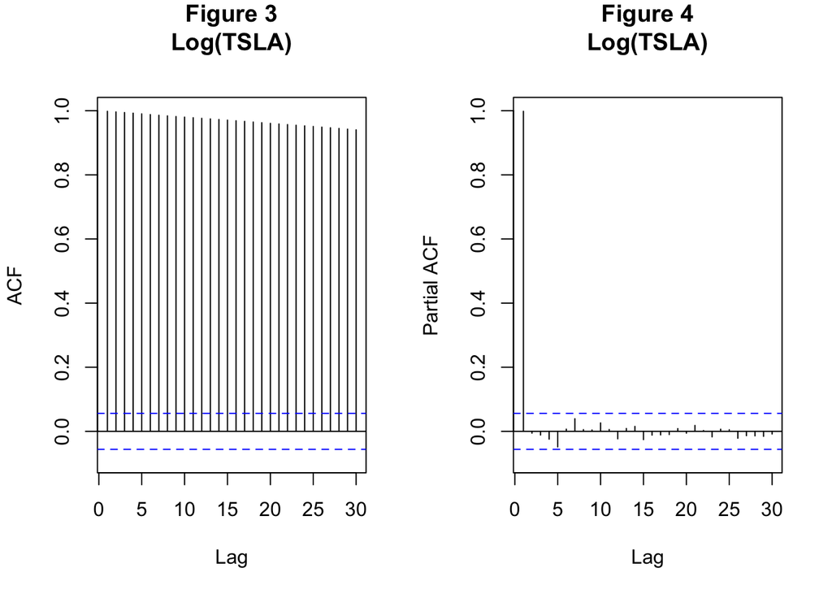

```r
par(mfrow=c(1,2))
Acf(log.tsla, main = "Figure 3\nLog(TSLA)")
Pacf(log.tsla, main = "Figure 4\nLog(TSLA)")
```

Here is the first difference, along with the ACF and PACF:

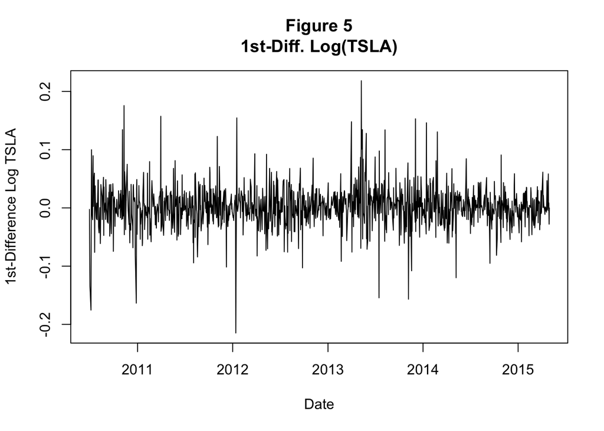

```r
## Add code to compute the first difference and make the plots.
diff.log.tsla <- c(NA, diff(log.tsla))

par(mfrow=c(1,1))
plot(date, diff.log.tsla, type="l",
     xlab="Date", ylab="1st-Difference Log TSLA", main = "Figure 5\n1st-Diff. Log(TSLA)")
```

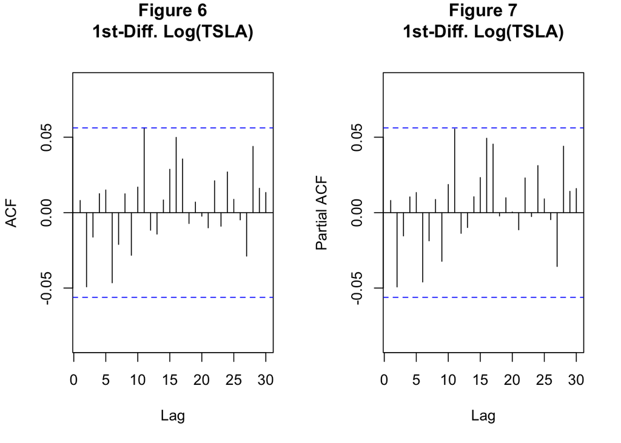

```r
par(mfrow=c(1,2))
Acf(diff.log.tsla, main = "Figure 6\n1st-Diff. Log(TSLA)")
Pacf(diff.log.tsla, main = "Figure 7\n1st-Diff. Log(TSLA)")
```

Here is the second difference, along with the ACF and PACF:

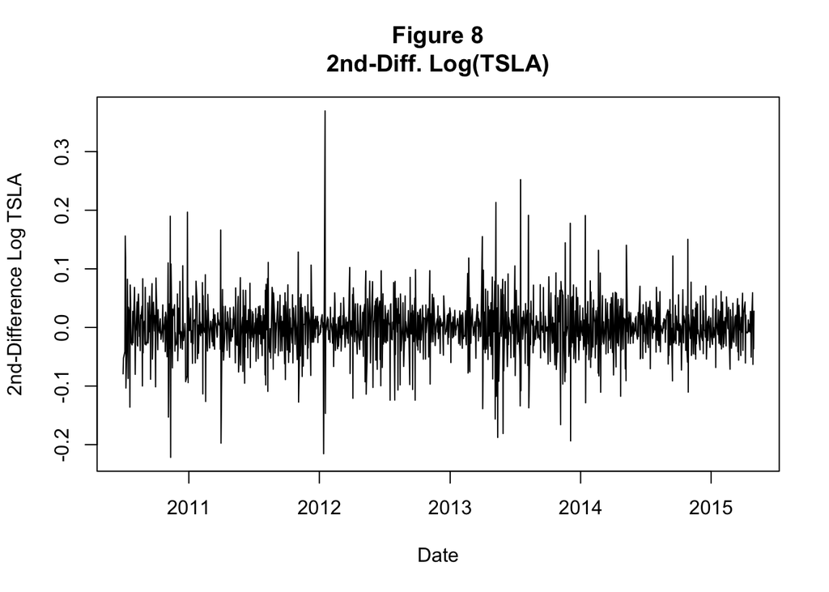

```r
## Add code to compute the second difference and make the plots.
diff2.log.tsla <- c(NA, diff(diff.log.tsla))

par(mfrow=c(1,1))
plot(date, diff2.log.tsla, type="l",
     xlab="Date", ylab="2nd-Difference Log TSLA", main="Figure 8\n2nd-Diff. Log(TSLA)")
```

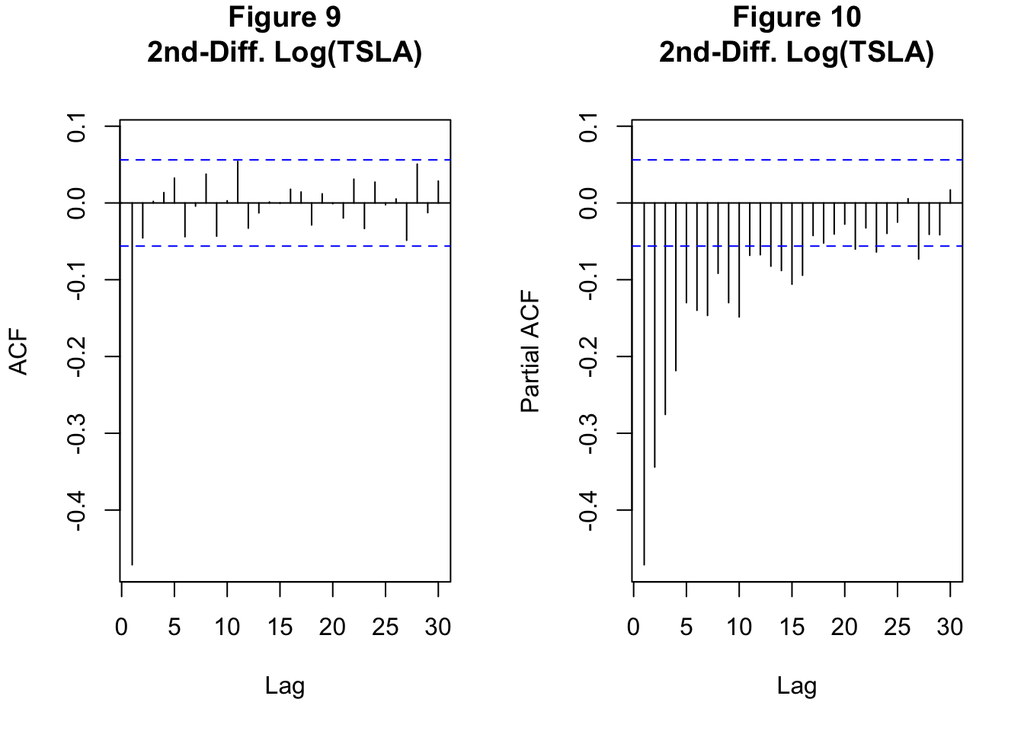

```r
par(mfrow=c(1,2))
Acf(diff2.log.tsla, main = "Figure 9\n2nd-Diff. Log(TSLA)")
Pacf(diff2.log.tsla, main = "Figure 10\n2nd-Diff. Log(TSLA)")
```

**Does the series appear to be stationary?**

**Can you identify an ARIMA(p,d,q) model from these plots?**

Similar to the rupee data, an ARIMA(0,1,0) seems to be the best fit as it shows now signs of autocorrelation.

## Problem 2

```r
d <- 1
aiccMin <- 0
# choose p, q with AICc
for (include.constant in c(FALSE, TRUE)) {
    for (p in 0:4) {
        for (q in 0:4) {
            # work-around bug in R by manually differencing
            fit <- Arima(diff(log.tsla), c(p,0,q), include.constant=include.constant, method="ML")
            cat("ARIMA(", p, ",", d, ",", q, ")(constant=", include.constant, ") : ", fit$aicc, "\n", sep="");

            if (fit$aicc < aiccMin)
              aiccMin <- fit$aicc
        }
    }
}
```

```
## ARIMA(0,1,0)(constant=FALSE) : -4675.46
## ARIMA(0,1,1)(constant=FALSE) : -4673.609
## ARIMA(0,1,2)(constant=FALSE) : -4674.117
## ARIMA(0,1,3)(constant=FALSE) : -4672.306
## ARIMA(0,1,4)(constant=FALSE) : -4670.419
## ARIMA(1,1,0)(constant=FALSE) : -4673.594
## ARIMA(1,1,1)(constant=FALSE) : -4672.374
## ARIMA(1,1,2)(constant=FALSE) : -4672.227
## ARIMA(1,1,3)(constant=FALSE) : -4670.287
## ARIMA(1,1,4)(constant=FALSE) : -4668.402
## ARIMA(2,1,0)(constant=FALSE) : -4674.209
## ARIMA(2,1,1)(constant=FALSE) : -4672.312
## ARIMA(2,1,2)(constant=FALSE) : -4674.613
## ARIMA(2,1,3)(constant=FALSE) : -4672.587
## ARIMA(2,1,4)(constant=FALSE) : -4667.371
## ARIMA(3,1,0)(constant=FALSE) : -4672.39
## ARIMA(3,1,1)(constant=FALSE) : -4670.375
## ARIMA(3,1,2)(constant=FALSE) : -4674.05
## ARIMA(3,1,3)(constant=FALSE) : -4669.173
## ARIMA(3,1,4)(constant=FALSE) : -4668.003
## ARIMA(4,1,0)(constant=FALSE) : -4670.592
## ARIMA(4,1,1)(constant=FALSE) : -4668.569
## ARIMA(4,1,2)(constant=FALSE) : -4670.169
## ARIMA(4,1,3)(constant=FALSE) : -4667.985
## ARIMA(4,1,4)(constant=FALSE) : -4669.765
## ARIMA(0,1,0)(constant=TRUE) : -4676.754
## ARIMA(0,1,1)(constant=TRUE) : -4674.831
## ARIMA(0,1,2)(constant=TRUE) : -4675.699
## ARIMA(0,1,3)(constant=TRUE) : -4674.007
## ARIMA(0,1,4)(constant=TRUE) : -4672.035
## ARIMA(1,1,0)(constant=TRUE) : -4674.823
## ARIMA(1,1,1)(constant=TRUE) : -4673.604
## ARIMA(1,1,2)(constant=TRUE) : -4673.913
## ARIMA(1,1,3)(constant=TRUE) : -4671.986
## ARIMA(1,1,4)(constant=TRUE) : -4670.013
## ARIMA(2,1,0)(constant=TRUE) : -4675.778
## ARIMA(2,1,1)(constant=TRUE) : -4673.972
## ARIMA(2,1,2)(constant=TRUE) : -4673.463
## ARIMA(2,1,3)(constant=TRUE) : -4672.629
## ARIMA(2,1,4)(constant=TRUE) : -4673.741
## ARIMA(3,1,0)(constant=TRUE) : -4674.071
## ARIMA(3,1,1)(constant=TRUE) : -4672.052
## ARIMA(3,1,2)(constant=TRUE) : -4672.752
## ARIMA(3,1,3)(constant=TRUE) : -4671.039
## ARIMA(3,1,4)(constant=TRUE) : -4669.135
## ARIMA(4,1,0)(constant=TRUE) : -4672.166
## ARIMA(4,1,1)(constant=TRUE) : -4670.141
## ARIMA(4,1,2)(constant=TRUE) : -4674.023
## ARIMA(4,1,3)(constant=TRUE) : -4669.169
## ARIMA(4,1,4)(constant=TRUE) : -4670.976
```

```r
print(aiccMin)
```

```
## [1] -4676.754
```

**Select an ARIMA(p,1,q) model.**

The best fitting model is the ARIMA(0,1,0) based on the AICC value of -4676.754. This model does consist of a constant. This holds consistent with our preliminary observation.

Here is code to fit the model, then compute residuals and the fitted values:

```r
(fit.mean <- Arima(log.tsla, c(0,1,0), include.constant=TRUE, method="ML"))
```

```
## Series: log.tsla
## ARIMA(0,1,0) with drift
##
## Coefficients:
##        drift
##       0.0018
## s.e.  0.0010
##
## sigma^2 estimated as 0.001256:  log likelihood=2338.46
## AIC=-4672.92   AICc=-4672.91   BIC=-4662.71
```

Here are the residuals, with the last 10 residuals printed out:

```r
resid <- as.numeric(residuals(fit.mean))
tail(resid, n=10)
```

```
##  [1] -0.009222598  0.018122869  0.044939796 -0.005680269 -0.002668759
##  [6]  0.056531020 -0.006476740  0.006666059 -0.029763933 -0.001933478
```

Here are the fitted values, with the last 10 fitted values printed out:

```r
f <- fitted.values(fit.mean)
tail(f, n=10)
```

```
##  [1] 5.333549 5.326171 5.346139 5.392924 5.389089 5.388265 5.446641
##  [8] 5.442009 5.450520 5.422601
```

Here is the one step ahead forecast and 95% forecast interval:

```r
forecast(fit.mean, h = 1, level = 95)
```

```
##      Point Forecast    Lo 95    Hi 95
## 1220       5.422513 5.353059 5.491966
```

## Problem 3

Here is a plot of the residuals:

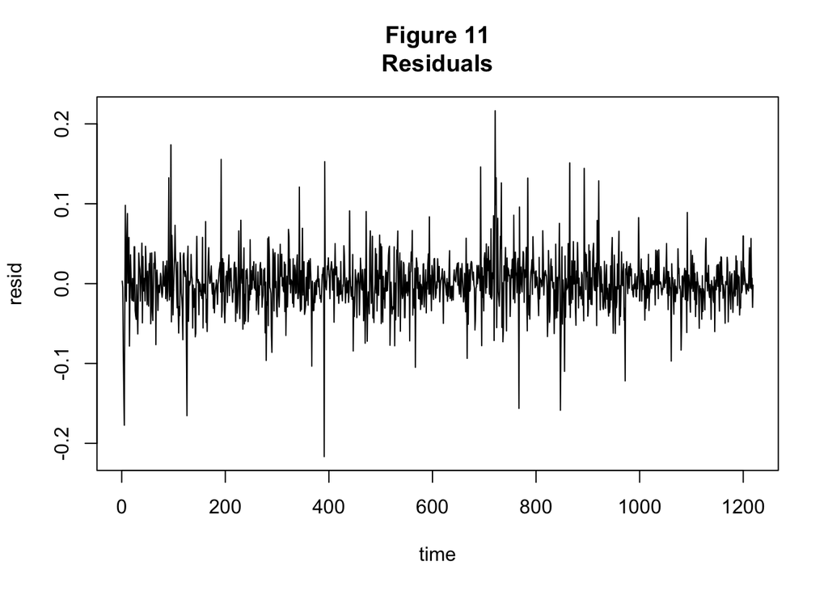

```r
# Add plot of the residuals.
par(mfrow=c(1,1))
plot(time, resid, type="l",  main = "Figure 11\nResiduals")
```

Here are an ACF and PACF of the residuals:

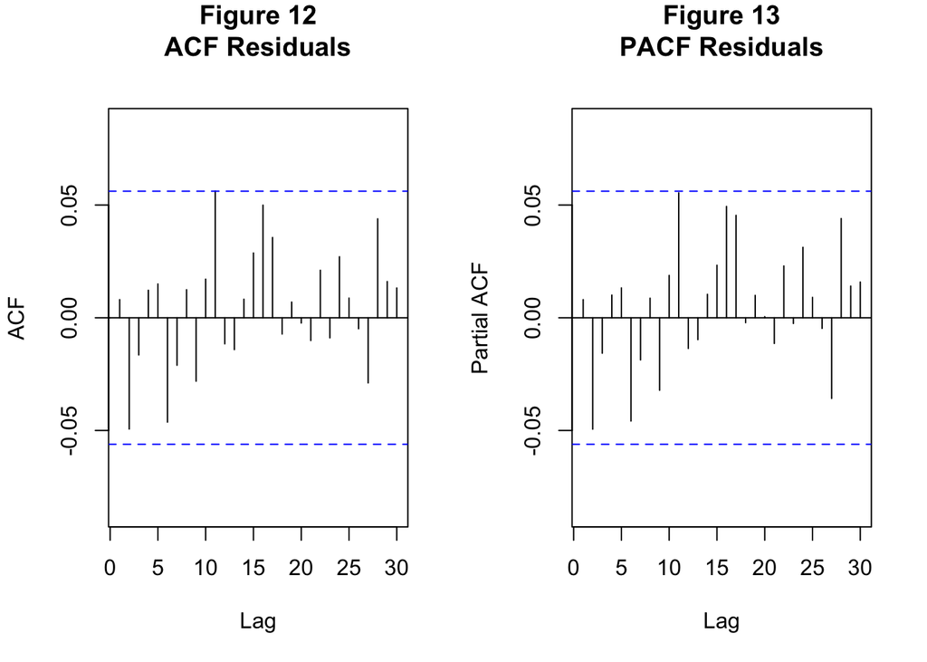

```r
par(mfrow=c(1,2))
Acf(resid,  main = "Figure 12\nACF Residuals")
Pacf(resid,  main = "Figure 13\nPACF Residuals")
```

Here are an ACF and PACF of the squared residuals:

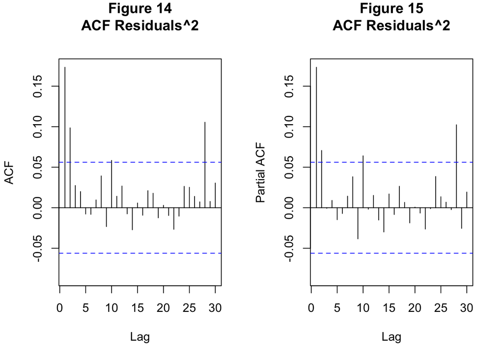

```r
par(mfrow=c(1,2))
Acf(resid^2, main = "Figure 14\nACF Residuals^2")
Pacf(resid^2, main = "Figure 15\nACF Residuals^2")
```

## Problem 4

Here are the AICc values for the ARCH(q):

```r
q <- 0:10
loglik <- rep(NA, length(q))
N <- length(resid)

for (i in 1:length(q)) {
    if (q[i] == 0) {
        loglik[i] <- -0.5 * N * (1 + log(2 * pi * mean(resid^2)))
    } else {
        fit <- garch(resid, c(0,q[i]), trace=FALSE)
        loglik[i] <- logLik(fit)
    }
}

k <- q + 1
aicc <- -2 * loglik  + 2 * k * N / (N - k - 1)

print(data.frame(q, loglik, aicc))
```

```
##     q   loglik      aicc
## 1   0 2342.799 -4683.596
## 2   1 2363.015 -4722.020
## 3   2 2372.741 -4739.463
## 4   3 2373.974 -4739.916
## 5   4 2378.170 -4746.290
## 6   5 2378.180 -4744.291
## 7   6 2375.596 -4737.099
## 8   7 2375.711 -4735.303
## 9   8 2375.681 -4733.212
## 10  9 2373.252 -4726.321
## 11 10 2377.085 -4731.950
```

Here is the AICc for the GARCH(1,1):

```r
fit <- garch(resid, c(1,1), trace=FALSE)
loglik <- logLik(fit)
k <- 2
aicc <- -2 * loglik  + 2 * k * N / (N - k - 1)

print(data.frame(loglik, aicc))
```

```
##     loglik      aicc
## 1 2373.986 -4743.962
```

Here are the summary and log likelihood of the selected model:

```r
fit.var <- garch(resid, c(0,4), trace=FALSE)
summary(fit.var)
```

```
##
## Call:
## garch(x = resid, order = c(0, 4), trace = FALSE)
##
## Model:
## GARCH(0,4)
##
## Residuals:
##      Min       1Q   Median       3Q      Max
## -7.01854 -0.51351 -0.02452  0.52268  5.32077
##
## Coefficient(s):
##     Estimate  Std. Error  t value Pr(>|t|)
## a0 8.928e-04   2.848e-05   31.345  < 2e-16 ***
## a1 1.164e-01   2.203e-02    5.283 1.27e-07 ***
## a2 1.385e-01   2.323e-02    5.960 2.52e-09 ***
## a3 7.864e-03   1.518e-02    0.518   0.6044
## a4 2.393e-02   7.704e-03    3.106   0.0019 **
## ---
## Signif. codes:  0 '***' 0.001 '**' 0.01 '*' 0.05 '.' 0.1 ' ' 1
##
## Diagnostic Tests:
##  Jarque Bera Test
##
## data:  Residuals
## X-squared = 1590.637, df = 2, p-value < 2.2e-16
##
##
##  Box-Ljung test
##
## data:  Squared.Residuals
## X-squared = 0.0154, df = 1, p-value = 0.9011
```

```r
logLik(fit.var)
```

```
## 'log Lik.' 2378.17 (df=5)
```

**Comment on the statistical significance of the parameter values of your selected model.**

## Problem 5

**Construct a 95% one step ahead forecast interval for the log exchange rate, based on your ARIMA-ARCH model.**

```r
coef(fit.var)
```

```
##           a0           a1           a2           a3           a4
## 0.0008928136 0.1164106717 0.1384619199 0.0078637695 0.0239278638
```

```r
(omega <- coef(fit.var)[[1]])
```

```
## [1] 0.0008928136
```

```r
(alpha <- coef(fit.var)[-1])
```

```
##          a1          a2          a3          a4
## 0.116410672 0.138461920 0.007863769 0.023927864
```

```r
observations <- (resid^2)[1216:1219]

(h1 <- omega + sum(alpha * observations))
```

```
## [1] 0.0009109054
```

```r
f1 <- as.numeric(forecast(fit.mean, h=1)$mean)

# ARIMA-ARCH inteval
f1 + sqrt(h1) * c(-1.96, 1.96) # 95%
```

```
## [1] 5.363358 5.481668
```

**Compare this to the interval based on the ARIMA only model from Problem 2.**

## Problem 6

Here are the conditional variances, with the last 10 values printed out:

```r
ht <- fit.var$fit[,1]^2 # ARIMA-ARCH
tail(ht, n=10)
```

```
##  [1] 0.0009044400 0.0009034090 0.0009441140 0.0011741075 0.0011808232
##  [6] 0.0009218506 0.0013143979 0.0013410154 0.0009290958 0.0010788910
```

Here is a plot of the conditional variances:

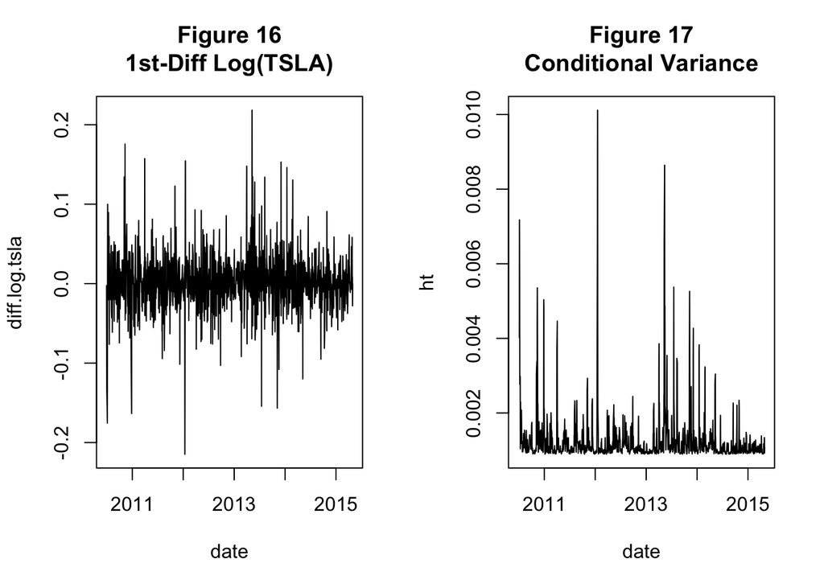

```r
par(mfrow=c(1,2))
plot(date, diff.log.tsla, type="l", main = "Figure 16\n1st-Diff Log(TSLA)")
plot(date, ht, type="l", main = "Figure 17\nConditional Variance")
```

**Use this plot to locate bursts of high volatility.**

**Do these highly volatile periods agree with those found from examination of the time series plot of the log exchange rates themselves?**